# Aula2NovembroSemana7

Author

Laura Bettencourt

Published

November 2, 2026

# Reading and preparing the data

```r
obs_data <- read.csv("obs_data.csv")
seg_data <- read.csv("seg_data.csv")
obs_data$dist <- (obs_data$distbegin + obs_data$distend) / 2
obs_data$region <- factor(ifelse(obs_data$lat < 39, "South", "North"), levels = c("South", "North"))
# Add the temperature of the corresponding segment to each sighting.
segment_match <- match(obs_data$Sample.Label, seg_data$Sample.Label)
obs_data$SST_day <- seg_data$SST_day[segment_match]
# A segment may contain more than one sighting. For the first analysis,
# retain only one row per segment in which dolphins were detected.
detection_segments <- obs_data[!duplicated(obs_data$Sample.Label), ]
```

Confirm the dimensions of the objects and the number of missing values in the variables you will analyse.

```r
# Complete and run.
dim(obs_data)
```

```
[1] 737  18
```

```r
# 737 linhas e 18 colunas
```

What is the dimension of the object for analysis? The dimension of the segment object:

```r
dim(detection_segments)
```

```
[1] 650  18
```

Are there any NAs? (verificar se há dados not available)

```r
sum(is.na(detection_segments$SST_day))
```

```
[1] 0
```

Are there any NAs?

```r
sum(is.na(obs_data$size))
```

```
[1] 0
```

# Exercise 1 Before testing

## 1. the ecological question

Se os golfinhos se econtram em alguma temperatura específica, foi visto que apareciam em locais em que a temperatura era menor que 20ºC  
OU  
Might our sample of observations be consistent with dolphins preferring tempertures below 20ºC?

## 2. the sampling unit (unidade de amostragem)

The sampling units are segments of effort with dolphins detected on them. We have 650 of these.  
OU

```r
nrow(detection_segments)
```

```
[1] 650
```

## 3. the response variable and its measurement scale (variável de resposta)

A temperatura  
The temperature, and it is a continuous variable

## 4. The null hypothesis $H_0$ and alternative $H_1$, using symbols and words

hipotese nula é menor ou igual a 20ºC hipotese alternativa é maior ou igual a 20ºC

$H_0: \mu \le 20$

the mean value of segments where dolphins exist is less or equal to 20

$H_1: \mu > 20$

## 5. the significance level

alfa = 0.01  
I will choose 0.01, i only want to find a non existing effect 1 out of every 100 times i would conduct the test.

## 6. the relevant assumptions

The assumptions (of a parametric teste over the mean) are:  
1. the observations should be independent

2. the residuals (here it is the same as the observations) should be Gaussian

## Also answer:

## Can independence be confirmed with a normality test?

## Can sightings made in the same segment, day or region automatically be treated as independent?

## Why should the choice between a one-sided and two-sided test be made before examining the result?

# Exercise 2 One-sample test

## Question

In segments containing at least one detection, is the mean sea-surface temperature compatible with 20 °C?

Use a two-sided test with (H_0: = 20) °C. This question describes conditions in segments with detections. On its own, it is not a test of habitat preference because it does not compare segments with and without detections.

## 4.2 Exploration and assumptions

**1. Calculate (n), the mean, median, standard deviation and standard error.**

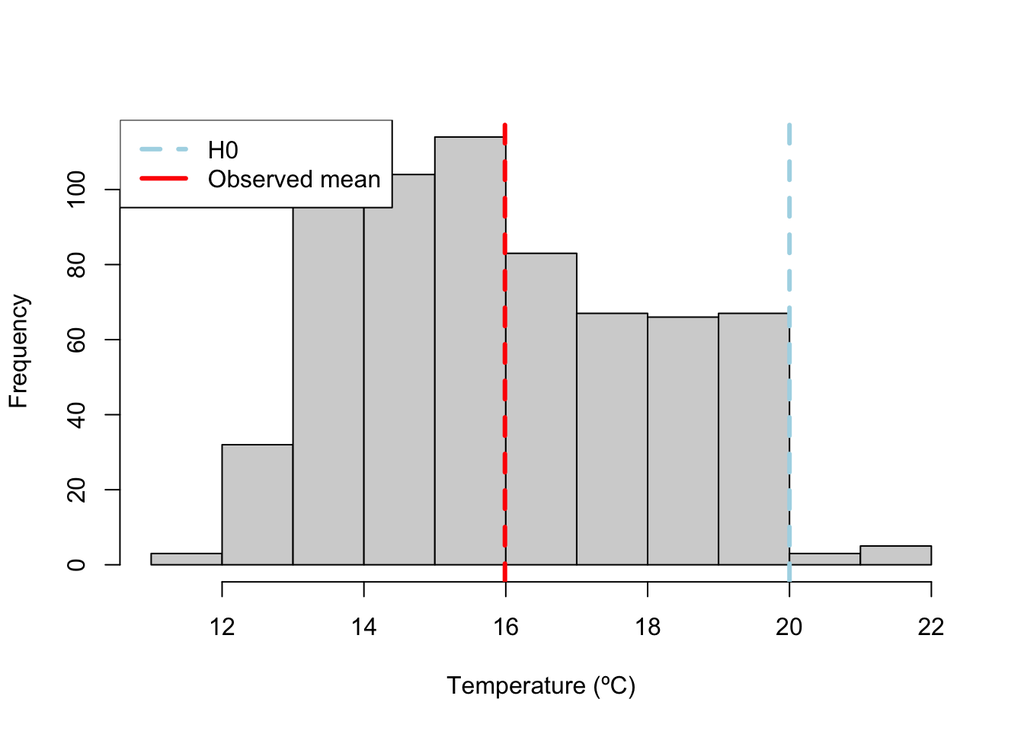

```r
hist(detection_segments$SST_day, main="", xlab="Temperature (ºC)")
abline(v=20,lty=2,lwd=3,col="lightblue")
abline(v=mean(detection_segments$SST_day),lty=2,lwd=3,col="red")
legend("topleft", lty=c(2,1), lwd=3, col=c("lightblue","red"), legend=c("H0","Observed mean"))
```

```r
mean(detection_segments$SST_day)
```

```
[1] 15.98786
```

```r
sd(detection_segments$SST_day)
```

```
[1] 2.144974
```

```r
range(detection_segments$SST_day)
```

```
[1] 11.60633 21.62986
```

The minimum value of SST where a dolphin was observed was 11.61 the maximum was 21.6298564 and the mean was 15.9878631 ºC.

**2. Evaluate the assumptions of a parametric test for the mean**

i will use a kolmogrov-smirnov test for gaussanity. first need to standardize the data

```r
#standardizar os dados
#subtrair a media e dividir pelo desvio padrao
scaledSST <- detection_segments$SST_day - mean(detection_segments$SST_day)/sd(detection_segments$SST_day)
ks.test(scaledSST, y="pnorm")
```

```
    Asymptotic one-sample Kolmogorov-Smirnov test

data:  scaledSST
D = 0.99998, p-value < 2.2e-16
alternative hypothesis: two-sided
```

Given the p value, i should reject H0. that means that strictly i should use a non-parametric test.

Teste nao paramétrico

```r
wilcox.test(x=detection_segments$SST_day, mu=20, alternative ="two.sided")
```

```
    Wilcoxon signed rank test with continuity correction

data:  detection_segments$SST_day
V = 603, p-value < 2.2e-16
alternative hypothesis: true location is not equal to 20
```

But this was a bilateral test, but we want a unilateral test - remember our $H0$

```r
wilcox.test(x=detection_segments$SST_day, mu=20, alternative ="greater")
```

```
    Wilcoxon signed rank test with continuity correction

data:  detection_segments$SST_day
V = 603, p-value = 1
alternative hypothesis: true location is greater than 20
```

**3. Produce a histogram and a Q-Q plot.**

**4. Note: if you use `shapiro.test()`, mus be considering only on a reproducible subsample containing no more than 500 observations. Compare this result with the graphical assessment.**

**5. Discuss spatial and temporal independence. shapiro.test() cannot resolve this assumption**

### **4.3 The t-test and confidence interval**

run the test and identify the estimate, t estatistic, degrees of freedom, p-value and 95% confidence interval

implementei um teste de t, even if the assumption test tells me i should not

```r
myttestBi <- t.test(x=detection_segments$SST_day , mu =20, alternative = "two.sided",)
names(myttestBi)
```

```
 [1] "statistic"   "parameter"   "p.value"     "conf.int"    "estimate"
 [6] "null.value"  "stderr"      "alternative" "method"      "data.name"
```

```r
myttestBi$conf.int
```

```
[1] 15.82266 16.15307
attr(,"conf.level")
[1] 0.95
```

```r
t.test(x=detection_segments$SST_day , mu=20, alternative = "greater",)
```

```
    One Sample t-test

data:  detection_segments$SST_day
t = -47.688, df = 649, p-value = 1
alternative hypothesis: true mean is greater than 20
95 percent confidence interval:
 15.84928      Inf
sample estimates:
mean of x
 15.98786
```

**Explain why the confidence interval and the two-sided test lead to the same decision about 20°C.**

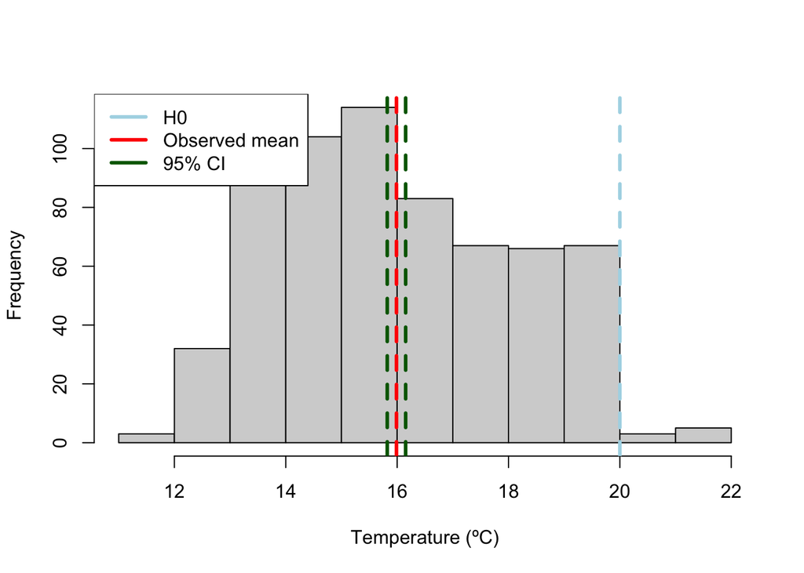

```r
hist(detection_segments$SST_day, main="", xlab="Temperature (ºC)")
abline(v=20,lty=2,lwd=3,col="lightblue")
abline(v=mean(detection_segments$SST_day),lty=2,lwd=3,col="red")
legend("topleft", lty=c(1,1), lwd=3, col=c("lightblue","red","darkgreen"), legend=c("H0","Observed mean","95% CI"))

abline(v=myttestBi$conf.int,lty=2, col="darkgreen",lwd=3)
```

Que valores de $\mu$ me levariam a não rejeitar a H0

## 5 Exercise 3 Two independent samples

Does the mean size of observed groups differ north and south of 39° N?  
1. Write (H_0) and (H_1).  
2. Show the number of sightings in each region.  
3. Calculate the mean, median and standard deviation for each region.  
4. Visualise the distributions on the original scale and after applying log1p(size).

```r
table(obs_data$region)
```

```
South North
  296   441
```

We have 296 observations in the south and 441 in the north.

```r
mytab <- rbind(tapply(X=obs_data$size, INDEX = obs_data$region, FUN=mean), tapply(X=obs_data$size, INDEX = obs_data$region, FUN=median), tapply(X=obs_data$size, INDEX = obs_data$region, FUN=sd))
row.names(mytab) <- c("Mean","Median","Standard Deviation")
knitr::kable(mytab)
```

|  | South | North |
| --- | --- | --- |
| Mean | 10.65878 | 9.818594 |
| Median | 6.00000 | 5.000000 |
| Standard Deviation | 15.82280 | 15.915365 |

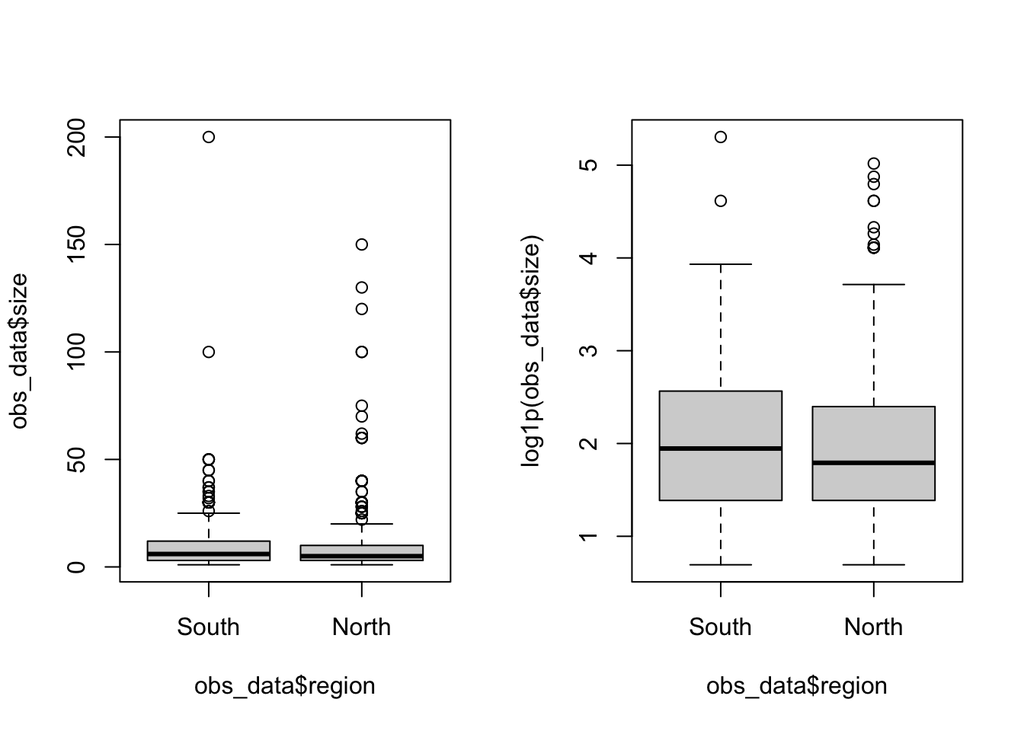

```r
par(mfrow = c(1, 2))
boxplot(obs_data$size ~ obs_data$region, data = obs_data)
boxplot(log1p(obs_data$size) ~ obs_data$region, data = obs_data)
```

Testar usando o teste de t

```r
t.test(x=obs_data$size[obs_data$region=="South"],y= obs_data$size[obs_data$region=="North"],alternative ="two.sided")
```

```
    Welch Two Sample t-test

data:  obs_data$size[obs_data$region == "South"] and obs_data$size[obs_data$region == "North"]
t = 0.70502, df = 635.28, p-value = 0.4811
alternative hypothesis: true difference in means is not equal to 0
95 percent confidence interval:
 -1.49999  3.18037
sample estimates:
mean of x mean of y
10.658784  9.818594
```

Testar usando o teste de wilcox, nível de significancia 0.01

```r
wilcox.test(x=obs_data$size[obs_data$region=="South"],y= obs_data$size[obs_data$region=="North"],alternative ="two.sided")
```

```
    Wilcoxon rank sum test with continuity correction

data:  obs_data$size[obs_data$region == "South"] and obs_data$size[obs_data$region == "North"]
W = 71364, p-value = 0.03087
alternative hypothesis: true location shift is not equal to 0
```

## Exercise 4 Paired comparison by year